# Problem Statement: AllLife Credit Card Customer Segmentation

## Background:

AllLife Bank wants to focus on its credit card customer base in the next financial year. They have been advised by their marketing research team, that the penetration in the market can be improved. Based on this input, the Marketing team proposes to run personalised campaigns to target new customers as well as upsell to existing customers. Another insight from the market research was that the customers perceive the support services of the back poorly. Based on this, the Operations team wants to upgrade the service delivery model, to ensure that customers queries are resolved faster. Head of Marketing and Head of Delivery both decide to reach out to the Data Science team for help.

## Objective:

To identify different segments in the existing customer based on their spending patterns as well as past interaction with the bank.

## Key Questions:

1. How many different segments of customers are there?
2. How are these segments different from each other?
3. What are your recommendations to the bank on how to better market to and service these customers?

## Data Description:

Data is of various customers of a bank with their credit limit, the total number of credit cards the customer has, and different channels through which customer has contacted the bank for any queries, different channels include visiting the bank, online and through a call centre.

## Steps to follow:

1. Perform univariate analysis on the data to better understand the variables at your disposal and to get an idea about the no of clusters. Perform EDA, create visualizations to explore data. (10 marks)
2. Properly comment on the codes, provide explanations of the steps taken in the notebook and conclude your insights from the graphs. (5 marks)
3. Execute K-means clustering use elbow plot and analyse clusters using boxplot (10 marks)
4. Execute hierarchical clustering (with different linkages) with the help of dendrogram and cophenetic coeff. Analyse clusters formed using boxplot (15 marks)
5. Calculate average silhouette score for both methods. (5 marks)
6. Compare K-means clusters with Hierarchical clusters. (5 marks)
7. Analysis the clusters formed, tell us how is one cluster different from another and answer all the key questions. (10 marks)

## Import Libraries and Load Dataset

```python
import warnings
warnings.filterwarnings('ignore')
```

```python
# Numerical libraries
import numpy as np

from sklearn.cluster import KMeans

# to handle data in form of rows and columns
import pandas as pd

# importing ploting libraries
import matplotlib.pyplot as plt

#importing seaborn for statistical plots
import seaborn as sns

from sklearn import metrics

import pandas as pd
```

```python
# Readinig the excel data into a dataframe
df = pd.read_excel('Credit_Card_Customer_Data.xlsx')
data = df.copy()
```

## Exploratory Data Analysis

```python
# Getting a feel of data , with first five rows.
data.head()
```

|  | Sl_No | Customer Key | Avg_Credit_Limit | Total_Credit_Cards | Total_visits_bank | Total_visits_online | Total_calls_made |
| --- | --- | --- | --- | --- | --- | --- | --- |
| 0 | 1 | 87073 | 100000 | 2 | 1 | 1 | 0 |
| 1 | 2 | 38414 | 50000 | 3 | 0 | 10 | 9 |
| 2 | 3 | 17341 | 50000 | 7 | 1 | 3 | 4 |
| 3 | 4 | 40496 | 30000 | 5 | 1 | 1 | 4 |
| 4 | 5 | 47437 | 100000 | 6 | 0 | 12 | 3 |

```python
data.shape
```

```
(660, 7)
```

**Insights:**

- `The dataset has 660 rows and 7 features`

```python
# Getting the data types of the dataset
data.info()
```

```
<class 'pandas.core.frame.DataFrame'>
RangeIndex: 660 entries, 0 to 659
Data columns (total 7 columns):
 #   Column               Non-Null Count  Dtype
---  ------               --------------  -----
 0   Sl_No                660 non-null    int64
 1   Customer Key         660 non-null    int64
 2   Avg_Credit_Limit     660 non-null    int64
 3   Total_Credit_Cards   660 non-null    int64
 4   Total_visits_bank    660 non-null    int64
 5   Total_visits_online  660 non-null    int64
 6   Total_calls_made     660 non-null    int64
dtypes: int64(7)
memory usage: 36.2 KB
```

```python
data.drop(['Sl_No', 'Customer Key'], axis=1, inplace=True)
```

**Note:**

- `Dropping 'Sl_No' and 'Customer Key' as those are not significant columns for clustering`

```python
# Getting the statistical details of the dataset
data.describe()
```

|  | Avg_Credit_Limit | Total_Credit_Cards | Total_visits_bank | Total_visits_online | Total_calls_made |
| --- | --- | --- | --- | --- | --- |
| count | 660.000000 | 660.000000 | 660.000000 | 660.000000 | 660.000000 |
| mean | 34574.242424 | 4.706061 | 2.403030 | 2.606061 | 3.583333 |
| std | 37625.487804 | 2.167835 | 1.631813 | 2.935724 | 2.865317 |
| min | 3000.000000 | 1.000000 | 0.000000 | 0.000000 | 0.000000 |
| 25% | 10000.000000 | 3.000000 | 1.000000 | 1.000000 | 1.000000 |
| 50% | 18000.000000 | 5.000000 | 2.000000 | 2.000000 | 3.000000 |
| 75% | 48000.000000 | 6.000000 | 4.000000 | 4.000000 | 5.000000 |
| max | 200000.000000 | 10.000000 | 5.000000 | 15.000000 | 10.000000 |

**Insights:**

```python
# Identifying the duplicate rows
duplicateRowsDF = data[df.duplicated()]
print("Duplicate Rows except first occurrence based on all columns are :")
print(duplicateRowsDF)
```

```
Duplicate Rows except first occurrence based on all columns are :
Empty DataFrame
Columns: [Avg_Credit_Limit, Total_Credit_Cards, Total_visits_bank, Total_visits_online, Total_calls_made]
Index: []
```

**Note:**

- `There is no duplicated data`

```python
# function to calculate the IQR and upper and lower bound range

def calculateIQR(col) :
  Q1 = np.percentile(col, 25, interpolation='midpoint')
  Q3 = np.percentile(col, 75, interpolation='midpoint')
  IQR = Q3-Q1
  lower_bound = Q1 -(1.5 * IQR)
  upper_bound = Q3 + (1.5 * IQR)
  return lower_bound, upper_bound
```

```python
print("Outliers details for the dataset :")
for col in data.columns :
  if data[col].dtypes in ('int64', "float64") :
    lower_range, upper_range = calculateIQR(data[col])
    print("---------------- " + col +  "--------------------------------------------")
    print("Count of upper-range outliers - ", data[data[col] > upper_range].shape[0])
    print("Percentage of upper-range outliers - ", (data[data[col] > upper_range].shape[0] / data.shape[0])* 100)
    print("Count of lower-range outliers - ", data[data[col] < lower_range].shape[0])
    print("Percentage of lower-range outliers - ", (data[data[col] < lower_range].shape[0] / data.shape[0]) * 100)
    print("---------------------------------------------------------------------")
```

```
Outliers details for the dataset :
---------------- Avg_Credit_Limit--------------------------------------------
Count of upper-range outliers -  39
Percentage of upper-range outliers -  5.909090909090909
Count of lower-range outliers -  0
Percentage of lower-range outliers -  0.0
---------------------------------------------------------------------
---------------- Total_Credit_Cards--------------------------------------------
Count of upper-range outliers -  0
Percentage of upper-range outliers -  0.0
Count of lower-range outliers -  0
Percentage of lower-range outliers -  0.0
---------------------------------------------------------------------
---------------- Total_visits_bank--------------------------------------------
Count of upper-range outliers -  0
Percentage of upper-range outliers -  0.0
Count of lower-range outliers -  0
Percentage of lower-range outliers -  0.0
---------------------------------------------------------------------
---------------- Total_visits_online--------------------------------------------
Count of upper-range outliers -  37
Percentage of upper-range outliers -  5.606060606060606
Count of lower-range outliers -  0
Percentage of lower-range outliers -  0.0
---------------------------------------------------------------------
---------------- Total_calls_made--------------------------------------------
Count of upper-range outliers -  0
Percentage of upper-range outliers -  0.0
Count of lower-range outliers -  0
Percentage of lower-range outliers -  0.0
---------------------------------------------------------------------
```

**Note:**

- `Total_visits_online has 5.60 percentage of the data as outliers`

```python
# Checking the skewness of the data
data.skew()
```

```
Avg_Credit_Limit       2.202396
Total_Credit_Cards     0.144879
Total_visits_bank      0.141896
Total_visits_online    2.225607
Total_calls_made       0.658905
dtype: float64
```

**Note:**

```python
# Function to display the displot for the columns.

def univariatePlots(data) :
  for col in data.columns :
    if (data[col].dtypes in ("int64", "float64")) :
      print("Distplot for numeric column : " , col);
      sns.displot(data[col], kde=True);
    plt.show()
```

```
Distplot for numeric column :  Avg_Credit_Limit
```

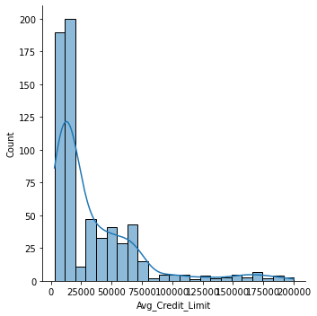

```
Distplot for numeric column :  Total_Credit_Cards
```

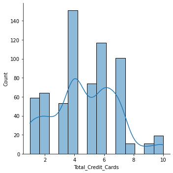

```
Distplot for numeric column :  Total_visits_bank
```

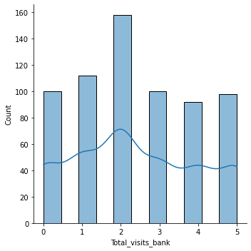

```
Distplot for numeric column :  Total_visits_online
```

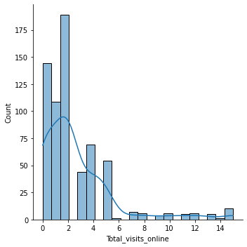

```
Distplot for numeric column :  Total_calls_made
```

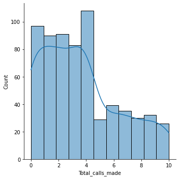

```python
univariatePlots(data)
```

**Insights:**

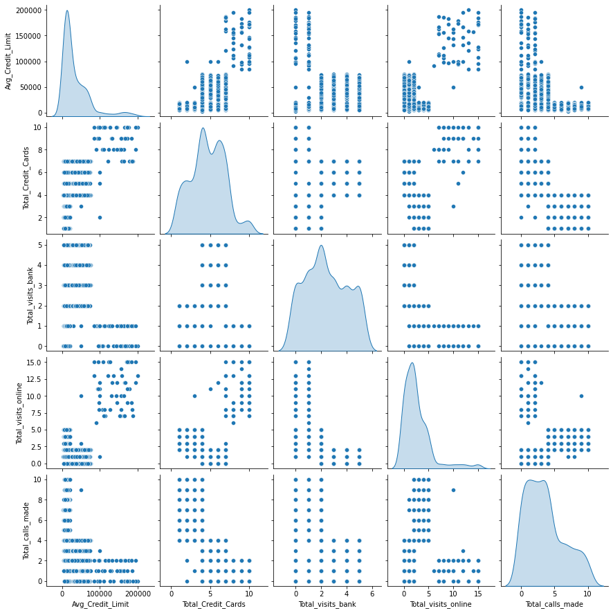

```python
# Displaying the pairplot for the dataset , with diagonals as kde

sns.pairplot(data, diag_kind='kde')
```

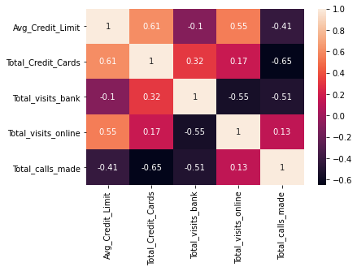

```python
# Getting the correlation of the features and displaying as a heatmap

corr = data.corr()
sns.heatmap(corr, annot=True)
```

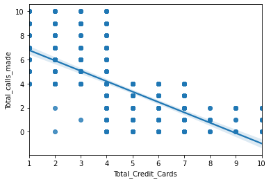

```python
sns.regplot(data['Total_Credit_Cards'], data['Total_calls_made'])
```

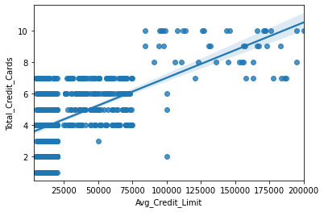

```python
sns.regplot(data['Avg_Credit_Limit'], data['Total_Credit_Cards'])
```

**Note:**

- `As we can see above :`

  ```
    - `Total_Credit_Cards and Total_calls_made have negative correlation`
    - `Avg_Credit_Limit and Total_Credit_Cards have positive correlation`
  ```

```python
# Hence , I am dropping the avg_credit_limit as it might not much significance to the clustering.

data.drop(['Avg_Credit_Limit'], axis=1, inplace=True)
```

```python
data.head()
```

|  | Total_Credit_Cards | Total_visits_bank | Total_visits_online | Total_calls_made |
| --- | --- | --- | --- | --- |
| 0 | 2 | 1 | 1 | 0 |
| 1 | 3 | 0 | 10 | 9 |
| 2 | 7 | 1 | 3 | 4 |
| 3 | 5 | 1 | 1 | 4 |
| 4 | 6 | 0 | 12 | 3 |

## K-means clustering

```python
# Importing the standard scaller to scale the dataset , so that its the distances beetween co ordinates are on the same scale.
from sklearn.preprocessing import StandardScaler

std_scaller = StandardScaler()

# Fitting the standard scaller with the dataset
scaller = std_scaller.fit(data)
```

```python
# Mean of the scaller fitted to the data

scaller.mean_
```

```
array([4.70606061, 2.4030303 , 2.60606061, 3.58333333])
```

```python
# Scalling the dataset using the transform function

scalled = scaller.transform(data)
data_s = pd.DataFrame(scalled, columns=data.columns)
data_s
```

|  | Total_Credit_Cards | Total_visits_bank | Total_visits_online | Total_calls_made |
| --- | --- | --- | --- | --- |
| 0 | -1.249225 | -0.860451 | -0.547490 | -1.251537 |
| 1 | -0.787585 | -1.473731 | 2.520519 | 1.891859 |
| 2 | 1.058973 | -0.860451 | 0.134290 | 0.145528 |
| 3 | 0.135694 | -0.860451 | -0.547490 | 0.145528 |
| 4 | 0.597334 | -1.473731 | 3.202298 | -0.203739 |
| ... | ... | ... | ... | ... |
| 655 | 2.443892 | -0.860451 | 2.520519 | -1.251537 |
| 656 | 2.443892 | -0.860451 | 3.543188 | -0.553005 |
| 657 | 1.520613 | -0.860451 | 2.179629 | -0.902271 |
| 658 | 2.443892 | -0.860451 | 4.224968 | -1.251537 |
| 659 | 1.982253 | -1.473731 | 3.202298 | -0.553005 |

660 rows × 4 columns

```python
data_s.shape
```

```
(660, 4)
```

```python
#Finding optimal no. of k mean clusters

from scipy.spatial.distance import cdist
clusters=range(1, 15)
meanDistortions=[]

for k in clusters:
    kmean_model = KMeans(n_clusters=k)
    kmean_model.fit(data_s)
    kmean_pred = kmean_model.predict(data_s)
    meanDistortions.append(sum(np.min(cdist(data_s, kmean_model.cluster_centers_, 'euclidean'), axis=1))/data_s.shape[0])
```

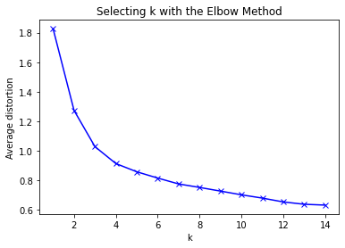

```python
# Plotting the mean distortion to show the elbow plot.

plt.plot(clusters, meanDistortions, 'bx-')
plt.xlabel('k')
plt.ylabel('Average distortion')
plt.title('Selecting k with the Elbow Method')
```

**Insights:**

- `Above elbow plot shows, the average distortion is no signifantly changing after 4 k mean values. Hence , taking k=4 could be a good clustering value.`

```python
# Preparing kmean clistering with k = 4

kmeans = KMeans(n_clusters=4, n_init=15, random_state=7)
kmeans.fit(data_s)
kmeans_pred = kmeans.predict(data_s)
```

```python
kmeans_pred
```

```
array([3, 0, 3, 3, 2, 0, 2, 3, 0, 0, 0, 0, 0, 0, 0, 0, 0, 0, 0, 0, 0, 0,
       0, 0, 0, 0, 0, 0, 0, 0, 0, 0, 0, 0, 0, 0, 0, 0, 0, 0, 0, 0, 3, 0,
       0, 0, 0, 0, 0, 0, 0, 0, 0, 0, 0, 0, 0, 0, 0, 0, 0, 0, 0, 0, 0, 0,
       0, 0, 0, 0, 0, 0, 0, 0, 0, 0, 0, 0, 0, 0, 0, 0, 0, 0, 0, 0, 0, 0,
       0, 0, 0, 0, 0, 0, 0, 0, 0, 0, 0, 0, 0, 0, 0, 0, 0, 0, 0, 0, 0, 0,
       0, 0, 0, 3, 0, 0, 0, 0, 0, 0, 0, 0, 0, 0, 0, 0, 0, 0, 0, 0, 0, 0,
       0, 0, 0, 0, 0, 0, 0, 0, 0, 0, 0, 0, 0, 0, 0, 0, 0, 0, 0, 0, 0, 0,
       0, 0, 0, 0, 0, 0, 0, 0, 0, 0, 0, 0, 0, 0, 0, 0, 0, 0, 0, 0, 0, 0,
       0, 0, 0, 0, 0, 0, 0, 0, 0, 0, 0, 0, 0, 0, 0, 0, 0, 0, 0, 0, 0, 0,
       0, 0, 0, 0, 0, 0, 0, 0, 0, 0, 0, 0, 0, 0, 0, 0, 0, 0, 0, 0, 0, 0,
       0, 0, 0, 0, 0, 0, 0, 0, 3, 3, 1, 3, 1, 3, 1, 1, 1, 1, 3, 3, 3, 1,
       3, 1, 3, 3, 1, 3, 1, 1, 3, 3, 1, 3, 3, 1, 3, 1, 3, 1, 1, 3, 1, 3,
       1, 1, 1, 1, 1, 1, 1, 3, 3, 1, 1, 3, 1, 1, 1, 1, 1, 3, 3, 3, 3, 1,
       1, 3, 3, 1, 3, 3, 3, 3, 1, 1, 1, 1, 1, 1, 1, 1, 3, 1, 1, 1, 3, 3,
       1, 1, 1, 3, 3, 3, 3, 3, 1, 1, 1, 3, 1, 1, 3, 3, 1, 1, 1, 1, 1, 1,
```

[output cut: 16 more lines]

```python
# Getting the co ordinates for the centroids for the kmeans

centroids = kmeans.cluster_centers_
centroids
```

```
array([[-1.070864  , -0.90505282,  0.33262581,  1.17110029],
       [ 0.35679514,  1.29571325, -0.54390138, -0.5750638 ],
       [ 1.86222621, -1.10576269,  2.82731942, -0.87432983],
       [ 0.37343847,  0.04107119, -0.55601194, -0.52331725]])
```

```python
#Adding column names to the centroids

centroid_kmeans = pd.DataFrame(centroids, columns = list(data) )
centroid_kmeans
```

|  | Total_Credit_Cards | Total_visits_bank | Total_visits_online | Total_calls_made |
| --- | --- | --- | --- | --- |
| 0 | -1.070864 | -0.905053 | 0.332626 | 1.171100 |
| 1 | 0.356795 | 1.295713 | -0.543901 | -0.575064 |
| 2 | 1.862226 | -1.105763 | 2.827319 | -0.874330 |
| 3 | 0.373438 | 0.041071 | -0.556012 | -0.523317 |

```python
# Labelling the final column and converting as a categorical attribute

kmeans_label = pd.DataFrame(kmeans_pred, columns= list(['labels']))
kmeans_label['labels'] = kmeans_label['labels'].astype('category')
kmeans_label.head()
```

|  | labels |
| --- | --- |
| 0 | 3 |
| 1 | 0 |
| 2 | 3 |
| 3 | 3 |
| 4 | 2 |

```python
# Joining the label dataframe with the data frame.

data_labeled = data.join(kmeans_label)
data_labeled.head()
```

|  | Total_Credit_Cards | Total_visits_bank | Total_visits_online | Total_calls_made | labels |
| --- | --- | --- | --- | --- | --- |
| 0 | 2 | 1 | 1 | 0 | 3 |
| 1 | 3 | 0 | 10 | 9 | 0 |
| 2 | 7 | 1 | 3 | 4 | 3 |
| 3 | 5 | 1 | 1 | 4 | 3 |
| 4 | 6 | 0 | 12 | 3 | 2 |

```python
# Getting the unique distribution among the labelled data
data_labeled['labels'].value_counts()
```

```
0    220
3    200
1    190
2     50
Name: labels, dtype: int64
```

```
array([[<AxesSubplot:title={'center':'Total_Credit_Cards'}, xlabel='[labels]'>,
        <AxesSubplot:title={'center':'Total_calls_made'}, xlabel='[labels]'>,
        <AxesSubplot:title={'center':'Total_visits_bank'}, xlabel='[labels]'>,
        <AxesSubplot:title={'center':'Total_visits_online'}, xlabel='[labels]'>],
       [<AxesSubplot:>, <AxesSubplot:>, <AxesSubplot:>, <AxesSubplot:>]],
      dtype=object)
```

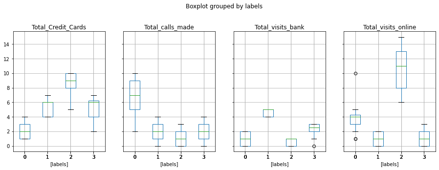

```python
# Displaying the category of the labelled data grouping  using box plots

data_labeled.boxplot(by = 'labels',  layout=(2,4), figsize=(15, 10))
```

## Hierarchical Clustering

```python
#hierarchical clustering using ward linkage

from sklearn.cluster import AgglomerativeClustering
from sklearn.metrics import silhouette_score

ward_model = AgglomerativeClustering(n_clusters=4, affinity='euclidean', linkage='ward')
ward_model.fit(data_s)

print("silhouette_score with ward linkage : " , silhouette_score(data_s, ward_model.labels_))
```

```
silhouette_score with ward linkage :  0.3729699784919786
```

```python
# Creating a datafrane joining the original data and labels generated from ward linkage clustering

ward_label = pd.DataFrame(ward_model.labels_, columns=list(['label_ward']))
ward_label['label_ward'] = ward_label['label_ward'].astype('category')
data_labelled_h = data.join(ward_label)

data_labelled_h.head()
```

|  | Total_Credit_Cards | Total_visits_bank | Total_visits_online | Total_calls_made | label_ward |
| --- | --- | --- | --- | --- | --- |
| 0 | 2 | 1 | 1 | 0 | 0 |
| 1 | 3 | 0 | 10 | 9 | 0 |
| 2 | 7 | 1 | 3 | 4 | 1 |
| 3 | 5 | 1 | 1 | 4 | 0 |
| 4 | 6 | 0 | 12 | 3 | 2 |

```python
# Getting the distribution for the ward labbeled data

data_labelled_h['label_ward'].value_counts()
```

```
0    225
1    211
3    174
2     50
Name: label_ward, dtype: int64
```

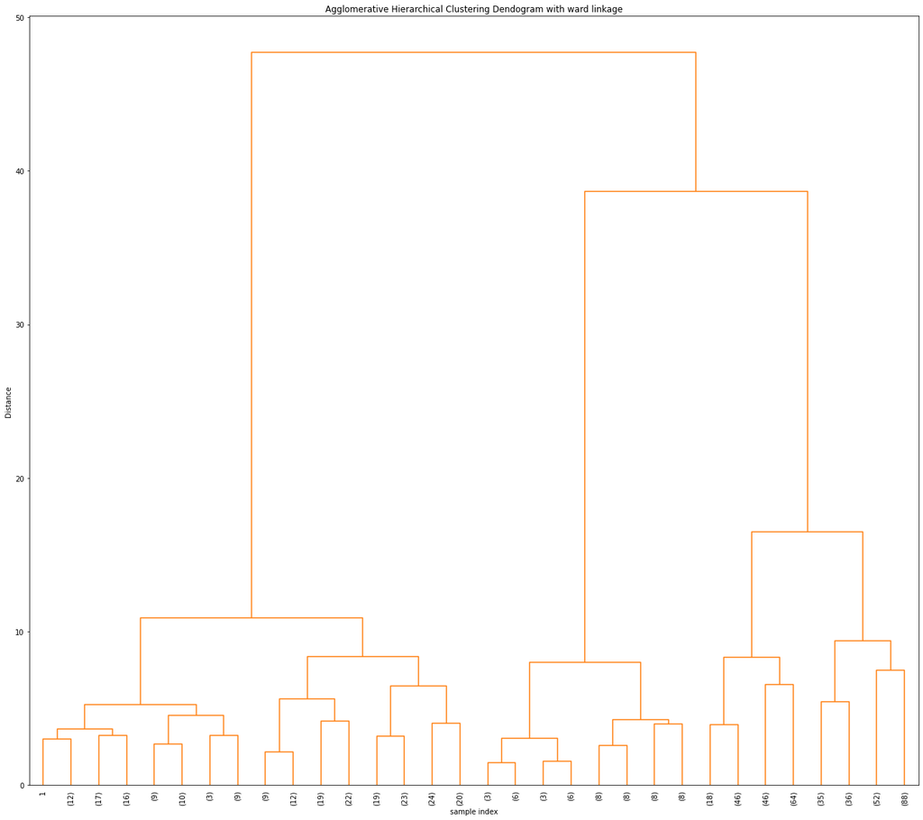

```python
# plotting dendogram with 'ward linkage'

from scipy.cluster.hierarchy import dendrogram, linkage
from scipy.spatial.distance import pdist
import matplotlib.pyplot as plt

plt.figure(figsize=(18, 16))
plt.title('Agglomerative Hierarchical Clustering Dendogram with ward linkage')
plt.xlabel('sample index')
plt.ylabel('Distance')
dendrogram(linkage(data_s, 'ward'), leaf_rotation=90.0, p=4,
           color_threshold=52, leaf_font_size=10, truncate_mode='level')
plt.tight_layout()
```

```
array([[<AxesSubplot:title={'center':'Total_Credit_Cards'}, xlabel='[label_ward]'>,
        <AxesSubplot:title={'center':'Total_calls_made'}, xlabel='[label_ward]'>,
        <AxesSubplot:title={'center':'Total_visits_bank'}, xlabel='[label_ward]'>,
        <AxesSubplot:title={'center':'Total_visits_online'}, xlabel='[label_ward]'>],
       [<AxesSubplot:>, <AxesSubplot:>, <AxesSubplot:>, <AxesSubplot:>]],
      dtype=object)
```

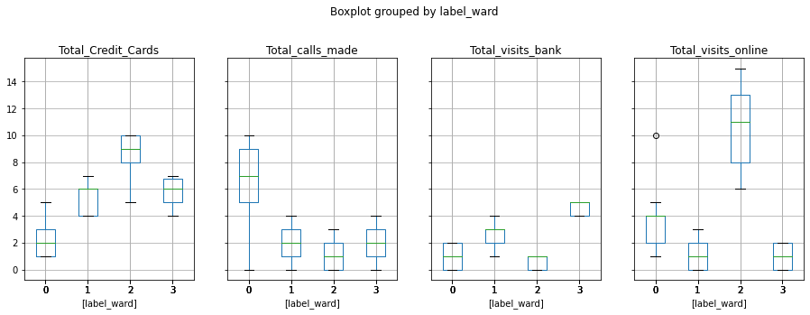

```python
# Plotting the box plots for the various labels
data_labelled_h.boxplot(by = 'label_ward',  layout=(2,4), figsize=(15, 10))
```

```python
# hierarchical clustering using single linkage

from sklearn.cluster import AgglomerativeClustering
from sklearn.metrics import silhouette_score

single_model = AgglomerativeClustering(n_clusters=4, affinity='euclidean', linkage='single')
single_model.fit(data_s)

print("silhouette_score with single linkage : " , silhouette_score(data_s, single_model.labels_))
```

```
silhouette_score with single linkage :  0.10389147178590387
```

```python
# Creating a datafrane joining the original data and labels generated from single linkage clustering

single_label = pd.DataFrame(single_model.labels_, columns=list(['label_single']))
single_label['label_single'] = single_label['label_single'].astype('category')
data_labelled_single = data.join(single_label)

data_labelled_single.head()
```

|  | Total_Credit_Cards | Total_visits_bank | Total_visits_online | Total_calls_made | label_single |
| --- | --- | --- | --- | --- | --- |
| 0 | 2 | 1 | 1 | 0 | 3 |
| 1 | 3 | 0 | 10 | 9 | 1 |
| 2 | 7 | 1 | 3 | 4 | 0 |
| 3 | 5 | 1 | 1 | 4 | 0 |
| 4 | 6 | 0 | 12 | 3 | 2 |

```python
# Getting the distribution of the clusters using single linkage

data_labelled_single['label_single'].value_counts()
```

```
0    608
2     50
3      1
1      1
Name: label_single, dtype: int64
```

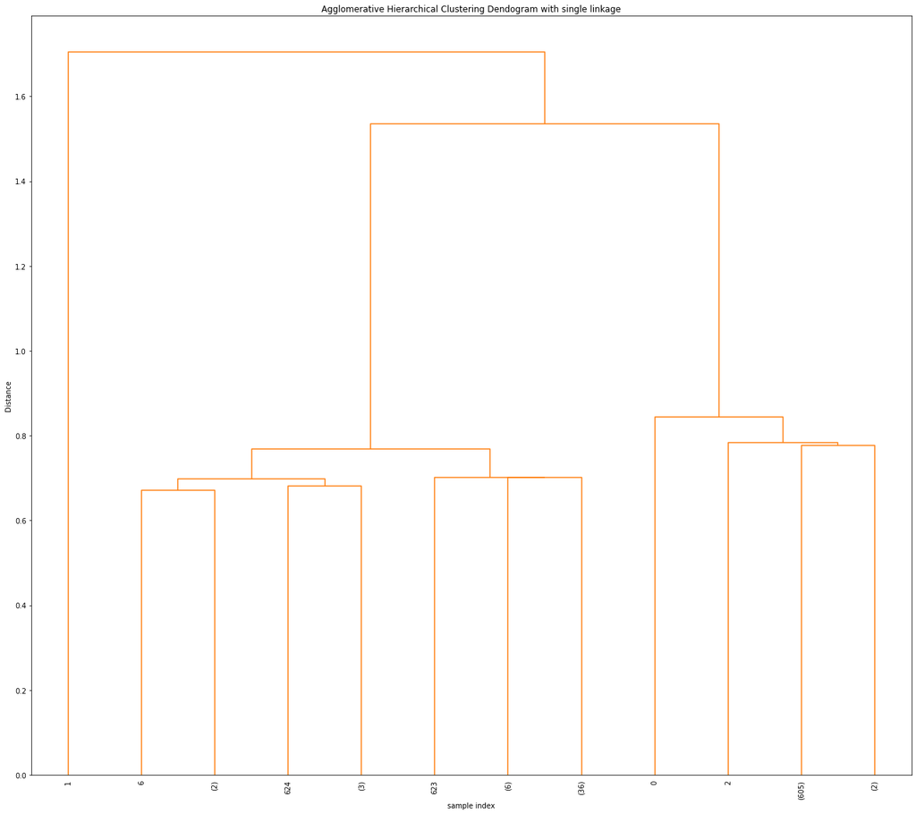

```python
# plotting dendogram with 'single linkage'

from scipy.cluster.hierarchy import dendrogram, linkage
from scipy.spatial.distance import pdist
import matplotlib.pyplot as plt

plt.figure(figsize=(18, 16))
plt.title('Agglomerative Hierarchical Clustering Dendogram with single linkage')
plt.xlabel('sample index')
plt.ylabel('Distance')
dendrogram(linkage(data_s, 'single'), leaf_rotation=90.0, p=4,
           color_threshold=52, leaf_font_size=10, truncate_mode='level')
plt.tight_layout()
```

```
array([[<AxesSubplot:title={'center':'Total_Credit_Cards'}, xlabel='[label_single]'>,
        <AxesSubplot:title={'center':'Total_calls_made'}, xlabel='[label_single]'>,
        <AxesSubplot:title={'center':'Total_visits_bank'}, xlabel='[label_single]'>,
        <AxesSubplot:title={'center':'Total_visits_online'}, xlabel='[label_single]'>],
       [<AxesSubplot:>, <AxesSubplot:>, <AxesSubplot:>, <AxesSubplot:>]],
      dtype=object)
```

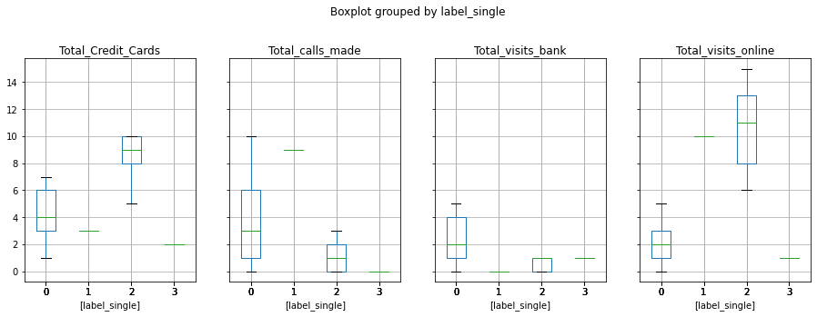

```python
# Plotting the box plots for the various labels

data_labelled_single.boxplot(by = 'label_single',  layout=(2,4), figsize=(15, 10))
```

```python
#hierarchical clustering using complete linkage

from sklearn.cluster import AgglomerativeClustering
from sklearn.metrics import silhouette_score

complete_model = AgglomerativeClustering(n_clusters=4, affinity='euclidean', linkage='complete')
complete_model.fit(data_s)

print("silhouette_score with complete linkage : " , silhouette_score(data_s, complete_model.labels_))
```

```
silhouette_score with complete linkage :  0.35410330488625136
```

```python
# Creating a datafrane joining the original data and labels generated from complete linkage clustering

complete_label = pd.DataFrame(complete_model.labels_, columns=list(['label_complete']))
complete_label['label_complete'] = complete_label['label_complete'].astype('category')
data_labelled_complete = data.join(complete_label)

data_labelled_complete.head()
```

|  | Total_Credit_Cards | Total_visits_bank | Total_visits_online | Total_calls_made | label_complete |
| --- | --- | --- | --- | --- | --- |
| 0 | 2 | 1 | 1 | 0 | 3 |
| 1 | 3 | 0 | 10 | 9 | 0 |
| 2 | 7 | 1 | 3 | 4 | 2 |
| 3 | 5 | 1 | 1 | 4 | 3 |
| 4 | 6 | 0 | 12 | 3 | 1 |

```python
# Getting the distribution of the clusters created by complete linkage

data_labelled_complete['label_complete'].value_counts()
```

```
2    385
0    213
1     50
3     12
Name: label_complete, dtype: int64
```

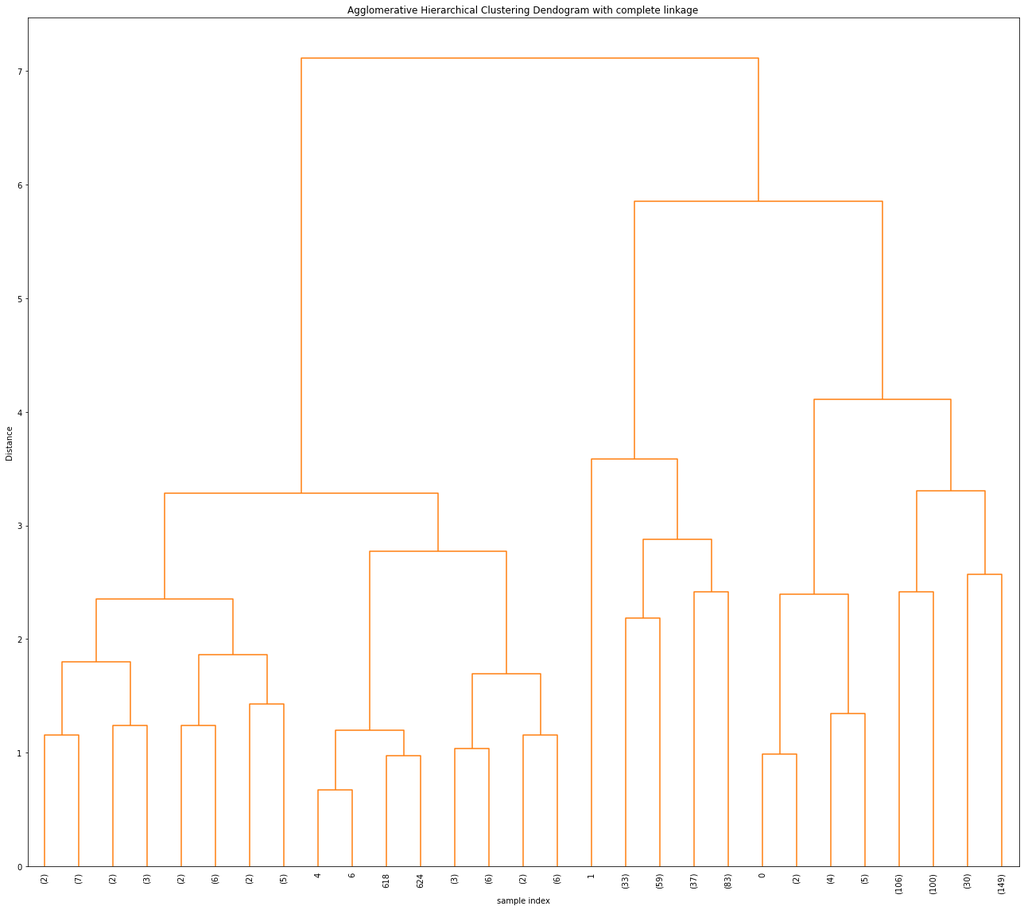

```python
# plotting dendogram with 'complete linkage'

from scipy.cluster.hierarchy import dendrogram, linkage
from scipy.spatial.distance import pdist
import matplotlib.pyplot as plt

plt.figure(figsize=(18, 16))
plt.title('Agglomerative Hierarchical Clustering Dendogram with complete linkage')
plt.xlabel('sample index')
plt.ylabel('Distance')
dendrogram(linkage(data_s, 'complete'), leaf_rotation=90.0, p=4,
           color_threshold=52, leaf_font_size=10, truncate_mode='level')
plt.tight_layout()
```

```
array([[<AxesSubplot:title={'center':'Total_Credit_Cards'}, xlabel='[label_complete]'>,
        <AxesSubplot:title={'center':'Total_calls_made'}, xlabel='[label_complete]'>,
        <AxesSubplot:title={'center':'Total_visits_bank'}, xlabel='[label_complete]'>,
        <AxesSubplot:title={'center':'Total_visits_online'}, xlabel='[label_complete]'>],
       [<AxesSubplot:>, <AxesSubplot:>, <AxesSubplot:>, <AxesSubplot:>]],
      dtype=object)
```

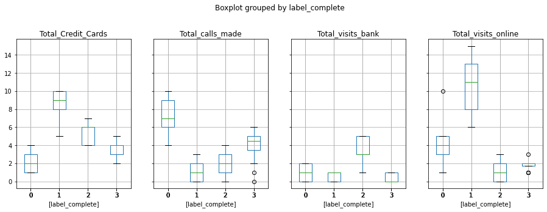

```python
# Plotting the box plots for the various labels

data_labelled_complete.boxplot(by = 'label_complete',  layout=(2,4), figsize=(15, 10))
```

```python
#hierarchical clustering using average linkage

from sklearn.cluster import AgglomerativeClustering
from sklearn.metrics import silhouette_score

average_model = AgglomerativeClustering(n_clusters=4, affinity='euclidean', linkage='average')
average_model.fit(data_s)

print("silhouette_score with complete linkage : " , silhouette_score(data_s, average_model.labels_))
```

```
silhouette_score with complete linkage :  0.496541564538832
```

```python
# Creating a datafrane joining the original data and labels generated from complete linkage clustering


average_label = pd.DataFrame(average_model.labels_, columns=list(['label_average']))
average_label['label_average'] = average_label['label_average'].astype('category')
data_labelled_average = data.join(average_label)

data_labelled_average.head()
```

|  | Total_Credit_Cards | Total_visits_bank | Total_visits_online | Total_calls_made | label_average |
| --- | --- | --- | --- | --- | --- |
| 0 | 2 | 1 | 1 | 0 | 0 |
| 1 | 3 | 0 | 10 | 9 | 3 |
| 2 | 7 | 1 | 3 | 4 | 2 |
| 3 | 5 | 1 | 1 | 4 | 0 |
| 4 | 6 | 0 | 12 | 3 | 1 |

```python
# Getting the distribution of the clusters using the average linkage

data_labelled_average['label_average'].value_counts()
```

```
2    385
0    224
1     50
3      1
Name: label_average, dtype: int64
```

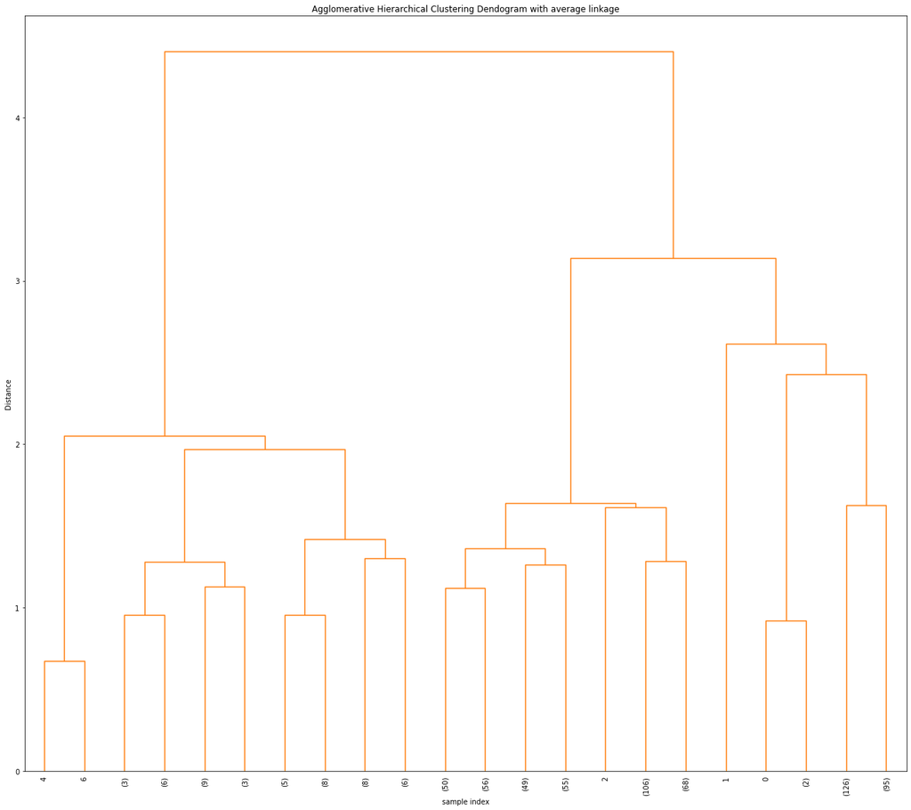

```python
# plotting dendogram with 'average linkage'

from scipy.cluster.hierarchy import dendrogram, linkage
from scipy.spatial.distance import pdist
import matplotlib.pyplot as plt

plt.figure(figsize=(18, 16))
plt.title('Agglomerative Hierarchical Clustering Dendogram with average linkage')
plt.xlabel('sample index')
plt.ylabel('Distance')
dendrogram(linkage(data_s, 'average'), leaf_rotation=90.0, p=4,
           color_threshold=52, leaf_font_size=10, truncate_mode='level')
plt.tight_layout()
```

```
array([[<AxesSubplot:title={'center':'Total_Credit_Cards'}, xlabel='[label_average]'>,
        <AxesSubplot:title={'center':'Total_calls_made'}, xlabel='[label_average]'>,
        <AxesSubplot:title={'center':'Total_visits_bank'}, xlabel='[label_average]'>,
        <AxesSubplot:title={'center':'Total_visits_online'}, xlabel='[label_average]'>],
       [<AxesSubplot:>, <AxesSubplot:>, <AxesSubplot:>, <AxesSubplot:>]],
      dtype=object)
```

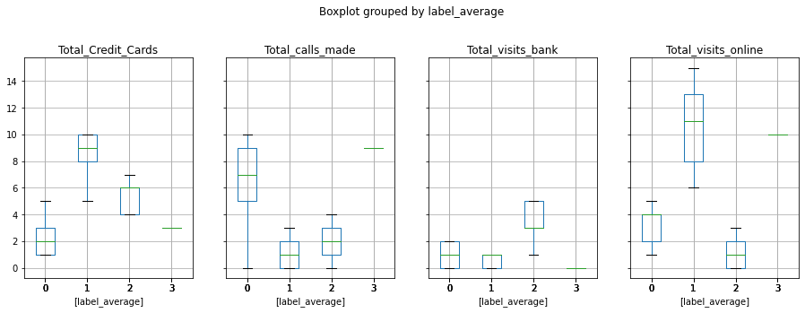

```python
# Plotting the box plots for the various labels

data_labelled_average.boxplot(by = 'label_average',  layout=(2,4), figsize=(15, 10))
```

## Calculate average silhouette score for both k-means and hierarchical clustering methods

```python
print("silhouette score for k-means with 4 clusters : ", silhouette_score(data_s, kmeans.labels_))
print("Avg. silhouette score for hierarchical clustering with 4 clusters : ",
      (silhouette_score(data_s, ward_model.labels_) + silhouette_score(data_s, single_model.labels_)
       +  silhouette_score(data_s, complete_model.labels_) + silhouette_score(data_s, average_model.labels_)) / 4)
```

```
silhouette score for k-means with 4 clusters :  0.3868799639660076
Avg. silhouette score for hierarchical clustering with 4 clusters :  0.3318765799257415
```

## Compare K-means clusters with Hierarchical clusters

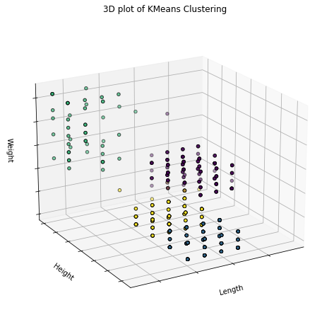

```python
# Demonstrate the 3d plot using mplot3d)
from mpl_toolkits.mplot3d import Axes3D

## 3D plots of k-means clusters

fig = plt.figure(figsize=(8, 6))
ax = Axes3D(fig, rect=[0, 0, .95, 1], elev=20, azim=60)
ax.scatter(data_s.iloc[:, 0], data_s.iloc[:, 1], data_s.iloc[:, 2],c=kmeans.labels_.astype(np.float), edgecolor='k')
ax.w_xaxis.set_ticklabels([])
ax.w_yaxis.set_ticklabels([])
ax.w_zaxis.set_ticklabels([])
ax.set_xlabel('Length')
ax.set_ylabel('Height')
ax.set_zlabel('Weight')
ax.set_title('3D plot of KMeans Clustering')
```

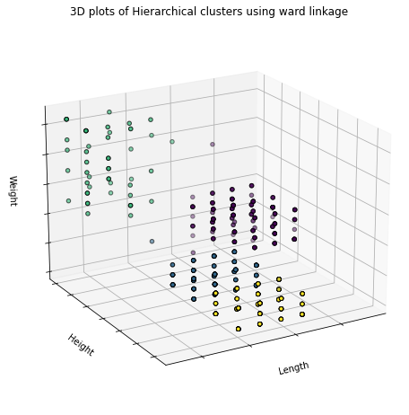

```python
## 3D plots of Hierarchical clusters using ward linkage

fig = plt.figure(figsize=(8, 6))
ax = Axes3D(fig, rect=[0, 0, .95, 1], elev=20, azim=60)
ax.scatter(data_s.iloc[:, 0], data_s.iloc[:, 1], data_s.iloc[:, 2],c=ward_model.labels_.astype(np.float), edgecolor='k')
ax.w_xaxis.set_ticklabels([])
ax.w_yaxis.set_ticklabels([])
ax.w_zaxis.set_ticklabels([])
ax.set_xlabel('Length')
ax.set_ylabel('Height')
ax.set_zlabel('Weight')
ax.set_title('3D plots of Hierarchical clusters using ward linkage')
```

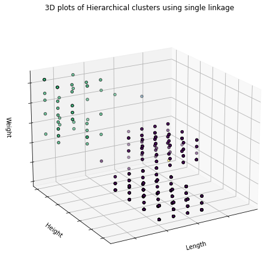

```python
## 3D plots of Hierarchical clusters using single linkage

fig = plt.figure(figsize=(8, 6))
ax = Axes3D(fig, rect=[0, 0, .95, 1], elev=20, azim=60)
ax.scatter(data_s.iloc[:, 0], data_s.iloc[:, 1], data_s.iloc[:, 2],c=single_model.labels_.astype(np.float), edgecolor='k')
ax.w_xaxis.set_ticklabels([])
ax.w_yaxis.set_ticklabels([])
ax.w_zaxis.set_ticklabels([])
ax.set_xlabel('Length')
ax.set_ylabel('Height')
ax.set_zlabel('Weight')
ax.set_title('3D plots of Hierarchical clusters using single linkage')
```

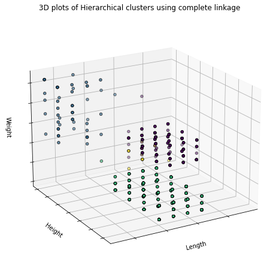

```python
## 3D plots of Hierarchical clusters using complete linkage

fig = plt.figure(figsize=(8, 6))
ax = Axes3D(fig, rect=[0, 0, .95, 1], elev=20, azim=60)
ax.scatter(data_s.iloc[:, 0], data_s.iloc[:, 1], data_s.iloc[:, 2],c=complete_model.labels_.astype(np.float), edgecolor='k')
ax.w_xaxis.set_ticklabels([])
ax.w_yaxis.set_ticklabels([])
ax.w_zaxis.set_ticklabels([])
ax.set_xlabel('Length')
ax.set_ylabel('Height')
ax.set_zlabel('Weight')
ax.set_title('3D plots of Hierarchical clusters using complete linkage')
```

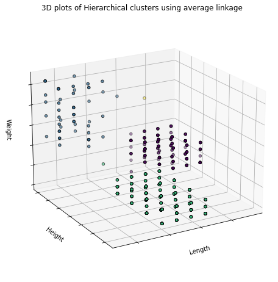

```python
## 3D plots of Hierarchical clusters using average linkage

fig = plt.figure(figsize=(8, 6))
ax = Axes3D(fig, rect=[0, 0, .95, 1], elev=20, azim=60)
ax.scatter(data_s.iloc[:, 0], data_s.iloc[:, 1], data_s.iloc[:, 2],c=average_model.labels_.astype(np.float), edgecolor='k')
ax.w_xaxis.set_ticklabels([])
ax.w_yaxis.set_ticklabels([])
ax.w_zaxis.set_ticklabels([])
ax.set_xlabel('Length')
ax.set_ylabel('Height')
ax.set_zlabel('Weight')
ax.set_title('3D plots of Hierarchical clusters using average linkage')
```

## Analysis the clusters formed, tell us how is one cluster different from another and answer all the key questions.

```python
# Getting the unique distribution among the labelled data for kmeans

data_labeled['labels'].value_counts()
```

```
0    220
3    200
1    190
2     50
Name: labels, dtype: int64
```

**Insights**

- `k-means : k-means clustering has seems somewhat uniformly data distribution among the 0,1,3 labels`
- `Label 2 has the minimum cluster size`

```
array([[<AxesSubplot:title={'center':'Total_Credit_Cards'}, xlabel='[labels]'>,
        <AxesSubplot:title={'center':'Total_calls_made'}, xlabel='[labels]'>,
        <AxesSubplot:title={'center':'Total_visits_bank'}, xlabel='[labels]'>,
        <AxesSubplot:title={'center':'Total_visits_online'}, xlabel='[labels]'>],
       [<AxesSubplot:>, <AxesSubplot:>, <AxesSubplot:>, <AxesSubplot:>]],
      dtype=object)
```

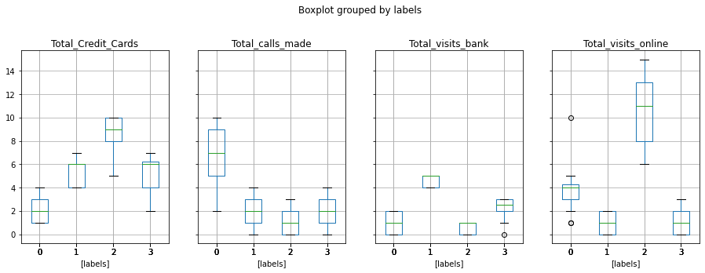

```python
# Plotting the box plots for the various labels using kmeans

data_labeled.boxplot(by = 'labels',  layout=(2,4), figsize=(15, 10))
```

**kmeans Insights**

- `Customers labeled as 0 seems to have less credit cards and have high total customer care calls and who prefer to visit online more over bank office visit`
- `Customers labeled as 1 seems to have medium credit cards and have less total customer care calls and who prefer to visit bank office more over online visits`
- `Customers labeled as 2 seems to have high credit cards and have low total customer care calls and customers who visit online the most`
- `Customers labeled as 3 seems to have medium credit cards and have less customer care engagement , have low total customer care calls`

```python
# Getting the distribution of the Hierarchical clusters

print('clusters distribution using ward linkage')
print(data_labelled_h['label_ward'].value_counts())

print('clusters distribution using single linkage')
print(data_labelled_single['label_single'].value_counts())

print('clusters distribution using complete linkage')
print(data_labelled_complete['label_complete'].value_counts())

print('clusters distribution using average linkage')
print(data_labelled_average['label_average'].value_counts())
```

```
clusters distribution using ward linkage
0    225
1    211
3    174
2     50
Name: label_ward, dtype: int64
clusters distribution using single linkage
0    608
2     50
3      1
1      1
Name: label_single, dtype: int64
clusters distribution using complete linkage
2    385
0    213
1     50
3     12
Name: label_complete, dtype: int64
clusters distribution using average linkage
2    385
0    224
1     50
3      1
Name: label_average, dtype: int64
```

```
array([[<AxesSubplot:title={'center':'Total_Credit_Cards'}, xlabel='[label_average]'>,
        <AxesSubplot:title={'center':'Total_calls_made'}, xlabel='[label_average]'>,
        <AxesSubplot:title={'center':'Total_visits_bank'}, xlabel='[label_average]'>,
        <AxesSubplot:title={'center':'Total_visits_online'}, xlabel='[label_average]'>],
       [<AxesSubplot:>, <AxesSubplot:>, <AxesSubplot:>, <AxesSubplot:>]],
      dtype=object)
```

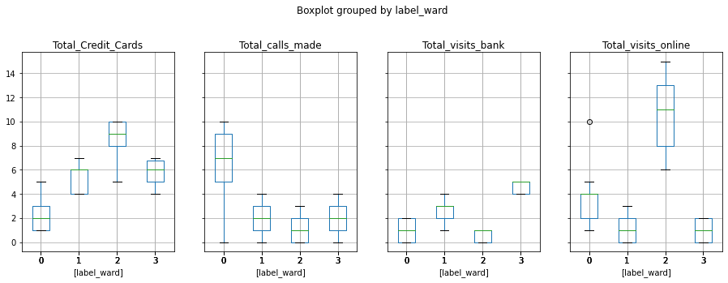

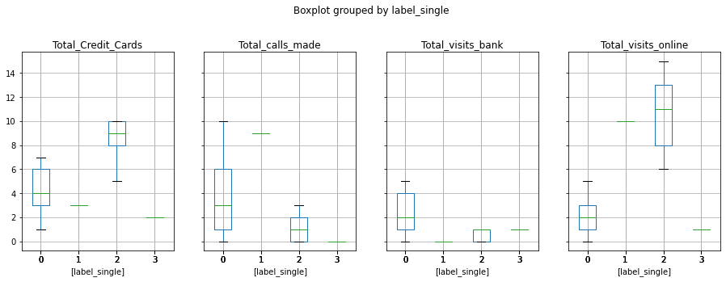

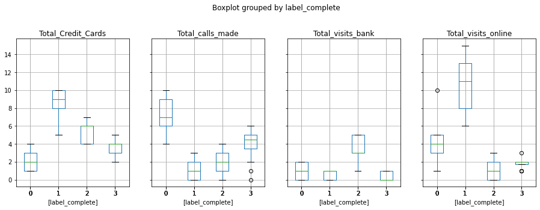

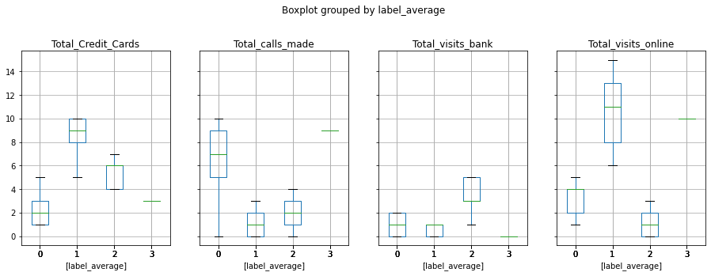

```python
# Plotting the box plots for the various labels using the Hierarchical clusters

data_labelled_h.boxplot(by = 'label_ward',  layout=(2,4), figsize=(15, 10))
data_labelled_single.boxplot(by = 'label_single',  layout=(2,4), figsize=(15, 10))
data_labelled_complete.boxplot(by = 'label_complete',  layout=(2,4), figsize=(15, 10))
data_labelled_average.boxplot(by = 'label_average',  layout=(2,4), figsize=(15, 10))
```

**Hierarchical clusters Insights**

- `As we see in above comparisions , hierarchical clustering using ward linkage is the one that good clustering distribution`

**Note**

**Key Questions:**

- `Question : How are these segments different from each other? Answer :
  - Customers labeled as 0 seems to have less credit cards and have high total customer care calls and who prefer to visit online more over bank office visit
  - Customers labeled as 1 seems to have medium credit cards and have less total customer care calls and who prefer to visit bank office more over online visits
  - Customers labeled as 2 seems to have high credit cards and have low total customer care calls and customers who visit online the most
  - Customers labeled as 3 seems to have medium credit cards and have less customer care engagement , have low total customer care calls`
- `Question : What are your recommendations to the bank on how to better market to and service these customers? Answer : Customers labelled as 0 need to given more attention by the customer care , as they are the ones that have most number of calls made to customer care. Helping category label 0 customers would increase customer atisfaction to a significant level.

  Cutomers labbeled as 2 are the premium customer that have the higher number of credit cards and visit online website more often . These customers would be targetted for better online exprience and should be provided incentives to increase who can bring more revenue to the bank.

  Customers labelled as 1 and 3 , are more general customers who visit online and bank on a regular basis with specific needs. These customer needs to be take care the most.`